# Laporan Mahamami Bisnis — My sample book

[figure not shown]

# Prediksi tingkat kesuburan tanah untuk pemberian dosis pupuk dengan metode logistic Regression

[Soil Fertility Prediction - Hugging Face](https://huggingface.co/spaces/qiyaa/tugas1psd)

## 1. pendahuluan

### latar belakang

Kesuburan tanah merupakan salah satu faktor penting dalam pertanian untuk menentukan tingkat keberhasilan panen. Untuk bisa menentukan tingkat kesuburan sebuah tanah bisa melalui beberapa indikator yaitu tingkat Ph tanah, kandungan unsur hara tanah, tekstur tanah, warna tanah, dan masih banyak indikator lainnya penentu kesuburan tanah. Tanah yang subur bisa menyediakan unsur hara yang dibutuhkan oleh tanaman dalam kadar yang cukup. Namun, ada beberapa tanah yang memiliki tingkat kesuburan yang kurang baik sehingga membutuhkan bantuan melalui pupuk untuk bisa membantu proses pertumbuhan tanaman agar menghasilkan panen dengan kualitas yang baik dan bagus. Meskipun dengan pemberian pupuk bisa membantu tanah untuk bisa membantu proses pertumbuhan tanaman, pemberian pupuk tersebut juga harus sesuai dengan kadar yang seharusnya, karena jika kadar pupuk yang diberikan kurang atau lebih dari kadar seharusnya, hal tersebut juga bisa menghambat pertumbuhan tanaman.

### visi dan misi

Visi Menjadi perusahaan yang unggul dalam pengembangan sektor pertanian untuk meningkatkan nilai agribisnis Indonesia di kalangan dunia.

Misi Menjadi salah satu perusahaan yang berkontribusi untuk pembangunan sektor agribisnis untuk menyokong pembangunan bangsa.

### strategi bisnis

Strategi bisnis yang dibangun oleh perusahaan ini yaitu menciptakan prediksi terkait tingkat kesuburan tanah yang nantinya akan digunakan untuk media tanam untuk bisa mengetahui dosis pemberian pupuk yang sesuai dengan kondisi tanah tersebut. Jika dosis pemberian pupuk sudah sesuai dengan kadar nutrisi yang dibutuhkan oleh tanah, diharapkan hasil panen dari tanaman tersebut memiliki kualitas yang baik. Melalui upaya tersebut diharapkan bisa menaikkan nilai jual produk pertanian di Indosenia agar bisa didistribusikan hingga ke luar negeri untuk meningkatkan nilai agribisnis di Indonesia.

### tujuan bisnis

Diperlukan adanya analisa terhadap kesuburan tanah tersebut untuk mengetahui karakteristik dari tanah tersebut beserta unsur hara yang terkandung didalamnya untuk mengetahui dosis pemberian pupuk yang cukup agar bisa menyokong pertumbuhan tanaman. Tujuan dari adanya bisnis ini, yaitu untuk mengetahui dosis pemberian pupuk pada tanah berdasarkan tingkat kesuburan tanah yang sudah diprediksi untuk menghindari adanya kelebihan ataupun kekurangan dosis pemberian pupuk pada suatu tanah untuk meminimalisir terjadinya gagal panen pada suatu tanaman.

### rumusan masalah

Masalah yang bisa muncul dalam penelitian ini yaitu terkait dengan sumber daya manusia yang ada, karena tidak sedikit masyakarat umum yang meremehkan terkait adanya penelitian seperti ini dikarenakan pemikiran mereka yang cenderung tidak peduli terkait perubahan yang bisa terjadi dengan adanya penelitian yang dilakukan oleh peneliti dengan tujuan untuk meningkatkan nilai panen.

## 2. data understanding

### deskripsi data

#### mengetahui tingkat kesuburan tanah untuk pemberin dosis pupuk

Analisis tingkat kesuburan tanah merupakan salah satu hal yang penting untuk dilakukan dalam dunia pertanian karena dari tingkat kesuburan tanah tersebut nantinya bisa diprediksi tingkat keberhasilan penanaman tanaman yang akan di budidayakan. Proses analisa tingkat kesuburan tanah bisa dimulai dengan melakukan analilsa terkait unsur hara yang terkandung dalam tanah tersebut ke dalam uji laboratorium. Unsur hara yang diuji di laboratorium terdiri dari Nitrogen, Fosfor, Kalium, pH, Electrical Conductivity, Organic Carbon, Sulfur, Zinc, Iron, Copper, Magnesium, dan juga boron. Nantinya dari hasil uji lab tersebut bisa digunakan untuk melakukan prediksi terkait banyaknya komposisi pemberian pupuk kepada tanah tersebut untuk mendukung pertumbuhan tanaman dengan baik untuk bis a menghasilkan panen yang memiliki kualitas terbaik.

```python
import pandas as pd
    from sklearn.model_selection import train_test_split
    from sklearn.linear_model import LogisticRegression
    from sklearn.metrics import accuracy_score, classification_report, confusion_matrix
    import seaborn as sns
    import matplotlib.pyplot as plt
```

#### menampilkan data

```python
import pandas as pd
    from sklearn.model_selection import train_test_split

    # Baca file CSV
    df = pd.read_csv('/content/drive/MyDrive/psd/soil fertility.csv')

    df
    # X = df[['N','P','K','pH','EC','OC','S','Zn','Fe','Cu','Mn','B']]
    # y = df['Output']
```

|  | N | P | K | pH | EC | OC | S | Zn | Fe | Cu | Mn | B | Output |
| --- | --- | --- | --- | --- | --- | --- | --- | --- | --- | --- | --- | --- | --- |
| 0 | 138 | 8.6 | 560 | 7.46 | 0.62 | 0.70 | 5.90 | 0.24 | 0.31 | 0.77 | 8.71 | 0.11 | 0 |
| 1 | 213 | 7.5 | 338 | 7.62 | 0.75 | 1.06 | 25.40 | 0.30 | 0.86 | 1.54 | 2.89 | 2.29 | 0 |
| 2 | 163 | 9.6 | 718 | 7.59 | 0.51 | 1.11 | 14.30 | 0.30 | 0.86 | 1.57 | 2.70 | 2.03 | 0 |
| 3 | 157 | 6.8 | 475 | 7.64 | 0.58 | 0.94 | 26.00 | 0.34 | 0.54 | 1.53 | 2.65 | 1.82 | 0 |
| 4 | 270 | 9.9 | 444 | 7.63 | 0.40 | 0.86 | 11.80 | 0.25 | 0.76 | 1.69 | 2.43 | 2.26 | 1 |
| ... | ... | ... | ... | ... | ... | ... | ... | ... | ... | ... | ... | ... | ... |
| 875 | 351 | 10.7 | 623 | 7.96 | 0.51 | 0.29 | 7.24 | 0.36 | 4.69 | 0.69 | 11.03 | 0.69 | 1 |
| 876 | 264 | 9.0 | 486 | 7.24 | 0.47 | 0.10 | 3.92 | 0.35 | 8.26 | 0.45 | 7.98 | 0.40 | 1 |
| 877 | 276 | 9.2 | 370 | 7.62 | 0.62 | 0.49 | 6.64 | 0.42 | 3.57 | 0.63 | 6.48 | 0.32 | 1 |
| 878 | 320 | 13.8 | 391 | 7.38 | 0.65 | 1.07 | 5.43 | 0.58 | 4.58 | 1.02 | 13.25 | 0.53 | 2 |
| 879 | 264 | 10.3 | 475 | 7.49 | 0.74 | 0.88 | 10.56 | 0.45 | 7.36 | 1.87 | 10.63 | 0.63 | 0 |

880 rows × 13 columns

#### fitur

```python
import pandas as pd

    # Baca file CSV
    file_path = '/content/drive/MyDrive/psd/soil fertility.csv'
    data = pd.read_csv(file_path)

    # Tampilkan informasi tentang file CSV
    print("Informasi tentang file CSV:")
    data.info()
```

```
Informasi tentang file CSV:
    <class 'pandas.core.frame.DataFrame'>
    RangeIndex: 880 entries, 0 to 879
    Data columns (total 13 columns):
     #   Column  Non-Null Count  Dtype
    ---  ------  --------------  -----
     0   N       880 non-null    int64
     1   P       880 non-null    float64
     2   K       880 non-null    int64
     3   pH      880 non-null    float64
     4   EC      880 non-null    float64
     5   OC      880 non-null    float64
     6   S       880 non-null    float64
     7   Zn      880 non-null    float64
     8   Fe      880 non-null    float64
     9   Cu      880 non-null    float64
     10  Mn      880 non-null    float64
     11  B       880 non-null    float64
     12  Output  880 non-null    int64
    dtypes: float64(10), int64(3)
    memory usage: 89.5 KB
```

#### Penjelasan Fitur

Code diatas digunakan untuk menampilkan fitur-fitur yang digunakan dalam dataset ini, selain menampilkan fitur yang digunakan pada code diatas juga menampilkan class yang digunakan yaitu terletak pada Output, code diatas juga digunakan untuk menampilkan jenis tipe data yang digunakan pada masing-masing fitur yaitu numerik. N : Nitrogen adalah salah satu unsur makronutrien utama yang dibutuhkan tanaman. Nitrogen sangat penting dalam proses pertumbuhan, terutama dalam pembentukan protein, enzim, dan klorofil. Kekurangan nitrogen dapat menyebabkan pertumbuhan tanaman terhambat, dengan daun menjadi kuning. Sebaliknya, terlalu banyak nitrogen dapat menyebabkan pertumbuhan vegetatif yang berlebihan, namun mengurangi produksi buah dan bunga. P : Fosfor merupakan elemen penting dalam pembentukan energi (ATP) pada tanaman, juga berperan dalam pembentukan akar yang kuat dan perkembangan bunga serta buah. Fosfor juga penting untuk kesehatan sistem akar dan membantu tanaman menyerap nutrisi lainnya dengan lebih efisien. Kekurangan fosfor biasanya mengakibatkan pertumbuhan lambat, terutama pada bagian akar. K : Kalium berperan dalam regulasi keseimbangan air dalam sel tanaman, serta dalam proses pembukaan dan penutupan stomata. Selain itu, kalium juga penting untuk ketahanan tanaman terhadap penyakit, membantu fotosintesis, dan transportasi nutrisi. Kandungan kalium yang cukup membuat tanaman lebih tahan terhadap stres seperti kekeringan dan penyakit. pH : pH tanah menentukan tingkat keasaman atau kebasaan tanah, yang mempengaruhi ketersediaan nutrisi bagi tanaman. Kebanyakan tanaman tumbuh optimal pada pH netral (sekitar 6-7). Tanah yang terlalu asam atau terlalu basa dapat menyebabkan defisiensi nutrisi tertentu atau toksisitas, sehingga penting untuk menjaga keseimbangan pH tanah. EC : EC adalah ukuran kemampuan tanah untuk menghantarkan arus listrik, yang secara tidak langsung mencerminkan tingkat salinitas (kandungan garam) dalam tanah. EC yang tinggi menunjukkan salinitas tinggi, yang bisa membahayakan tanaman karena mengganggu kemampuan akar menyerap air. Sebaliknya, EC yang terlalu rendah menunjukkan tanah mungkin kekurangan unsur garam mineral yang esensial. OC : organic carbon atau Karbon organik mengindikasikan jumlah bahan organik yang ada di dalam tanah, yang penting untuk kesehatan tanah secara keseluruhan. Tanah dengan kadar karbon organik yang tinggi cenderung lebih subur, memiliki struktur yang lebih baik, serta kemampuan yang lebih tinggi untuk menahan air dan nutrisi. Bahan organik juga mendukung kehidupan mikroba tanah yang membantu dalam proses dekomposisi dan penyediaan nutrisi bagi tanaman. S : Sulfur merupakan elemen penting dalam sintesis protein pada tanaman. Sulfur diperlukan untuk pembentukan asam amino, serta memainkan peran dalam pembentukan vitamin dan enzim tertentu. Tanaman yang kekurangan sulfur biasanya menunjukkan tanda-tanda mirip dengan kekurangan nitrogen, seperti daun yang menguning. Zn : Zinc adalah mikronutrien penting yang dibutuhkan tanaman dalam jumlah kecil, namun memiliki peran esensial dalam banyak proses enzimatik dan hormonal. Zinc berperan dalam sintesis protein, pembelahan sel, dan produksi hormon pertumbuhan. Kekurangan zinc sering menyebabkan kelainan pertumbuhan seperti daun yang kerdil atau berwarna pucat. Fe : Besi sangat penting untuk pembentukan klorofil dan, secara tidak langsung, untuk proses fotosintesis. Besi juga penting dalam transfer elektron dalam respirasi tanaman. Kekurangan besi biasanya mengakibatkan klorosis (daun menguning sementara urat daun tetap hijau), terutama pada tanaman muda. Cu : Tembaga adalah salah satu mikronutrien yang diperlukan dalam proses metabolisme enzim tanaman. Tembaga mendukung pembentukan lignin dalam dinding sel, yang penting untuk kekuatan struktural tanaman. Kekurangan tembaga dapat menyebabkan perubahan warna daun, seperti menguning atau layu, dan mempengaruhi kualitas buah. Mn : Mangan membantu dalam fotosintesis, terutama dalam proses fotolisis air. Selain itu, mangan juga berfungsi dalam aktivasi enzim yang terlibat dalam metabolisme nitrogen dan sintesis klorofil. Kekurangan mangan sering menyebabkan tanaman mengalami masalah pertumbuhan, seperti daun yang layu atau bintik-bintik coklat pada daun. B : Boron diperlukan untuk pembelahan sel dan perkembangan dinding sel pada tanaman. Kekurangan boron dapat menyebabkan masalah dalam perkembangan akar, bunga, dan buah. Boron juga mempengaruhi transportasi gula di dalam tanaman, yang penting untuk pembentukan buah dan biji.

#### class

```python
import pandas as pd

    # Baca file CSV
    file_path = '/content/drive/MyDrive/psd/soil fertility.csv'
    df_2 = pd.read_csv(file_path)

    # Hitung frekuensi nilai pada kolom 'quality'
    quality_counts = df_2['Output'].value_counts()

    # Tampilkan frekuensi nilai dari kolom 'quality'
    print("Frekuensi nilai di kolom 'output':")
    print(quality_counts)
```

```
Frekuensi nilai di kolom 'output':
    Output
    1    440
    0    401
    2     39
    Name: count, dtype: int64
```

#### Penjelasan Class

Class yang digunakan dalam dataset ini yaitu "Output" dimana class tersebut menjelaskan apakah dari prediksi dari masing-masing data tersebut tergolong tanah yang sudah atau tidak, untuk membedakan antara subur atau tidaknya suatu tanah maka dibedakan menggunakan angka dimana angka 1 digunakan ketika tanah tergolong subur, 0 digunakan untuk tanah yang tergolong tidak subur, dan 2 digunakan ketika tanah tidak tergolong pada kedua kategori yang tersedia atau bisa disebut berada di tengah-tengah antara subur dan tidak.

### identifikasi kualitas data

#### identifikasi outlier

```python
import pandas as pd
    from sklearn.neighbors import LocalOutlierFactor

    # Baca file CSV soil_fertility.csv
    file_path = '/content/drive/MyDrive/psd/soil fertility.csv'  # Ganti dengan path file kamu
    soil = pd.read_csv(file_path)

    # Simpan dataframe ke df_wine (sesuai dengan kode asli)
    soil_fertility = soil.copy()

    # Simpan kolom 'quality'
    wine_quality = soil_fertility[['Output']]

    # Hapus kolom 'quality' karena tidak digunakan dalam model LOF
    soil_fertility = soil_fertility.drop(['Output'], axis=1)

    # Inisialisasi dan fit model LOF
    lof = LocalOutlierFactor(n_neighbors=4, contamination=0.1)  # Set parameter LOF
    outlier_labels = lof.fit_predict(soil_fertility)

    # Tambahkan label outlier dan kolom 'quality' kembali ke dataframe
    soil_fertility['Outlier'] = outlier_labels
    soil_fertility['Output'] = wine_quality

    # Data yang sudah dibersihkan, tanpa outlier (optional)
    df_cleaned = soil_fertility[soil_fertility['Outlier'] != -1]

    # Tampilkan dataframe dengan label outlier dan kolom quality
    soil_fertility
```

|  | N | P | K | pH | EC | OC | S | Zn | Fe | Cu | Mn | B | Outlier | Output |
| --- | --- | --- | --- | --- | --- | --- | --- | --- | --- | --- | --- | --- | --- | --- |
| 0 | 138 | 8.6 | 560 | 7.46 | 0.62 | 0.70 | 5.90 | 0.24 | 0.31 | 0.77 | 8.71 | 0.11 | 1 | 0 |
| 1 | 213 | 7.5 | 338 | 7.62 | 0.75 | 1.06 | 25.40 | 0.30 | 0.86 | 1.54 | 2.89 | 2.29 | -1 | 0 |
| 2 | 163 | 9.6 | 718 | 7.59 | 0.51 | 1.11 | 14.30 | 0.30 | 0.86 | 1.57 | 2.70 | 2.03 | 1 | 0 |
| 3 | 157 | 6.8 | 475 | 7.64 | 0.58 | 0.94 | 26.00 | 0.34 | 0.54 | 1.53 | 2.65 | 1.82 | 1 | 0 |
| 4 | 270 | 9.9 | 444 | 7.63 | 0.40 | 0.86 | 11.80 | 0.25 | 0.76 | 1.69 | 2.43 | 2.26 | 1 | 1 |
| ... | ... | ... | ... | ... | ... | ... | ... | ... | ... | ... | ... | ... | ... | ... |
| 875 | 351 | 10.7 | 623 | 7.96 | 0.51 | 0.29 | 7.24 | 0.36 | 4.69 | 0.69 | 11.03 | 0.69 | 1 | 1 |
| 876 | 264 | 9.0 | 486 | 7.24 | 0.47 | 0.10 | 3.92 | 0.35 | 8.26 | 0.45 | 7.98 | 0.40 | 1 | 1 |
| 877 | 276 | 9.2 | 370 | 7.62 | 0.62 | 0.49 | 6.64 | 0.42 | 3.57 | 0.63 | 6.48 | 0.32 | 1 | 1 |
| 878 | 320 | 13.8 | 391 | 7.38 | 0.65 | 1.07 | 5.43 | 0.58 | 4.58 | 1.02 | 13.25 | 0.53 | 1 | 2 |
| 879 | 264 | 10.3 | 475 | 7.49 | 0.74 | 0.88 | 10.56 | 0.45 | 7.36 | 1.87 | 10.63 | 0.63 | 1 | 0 |

880 rows × 14 columns

#### identifikasi missing value

```python
import pandas as pd

    # Baca file CSV soil_fertility.csv
    file_path = '/content/drive/MyDrive/psd/soil fertility.csv'  # Ganti dengan path lokasi file CSV kamu
    soil = pd.read_csv(file_path)

    # Hitung jumlah nilai kosong (missing values) di setiap kolom
    df = soil.isnull().sum()

    # Tampilkan hasil
    df
```

|  | 0 |
| --- | --- |
| N | 0 |
| P | 0 |
| K | 0 |
| pH | 0 |
| EC | 0 |
| OC | 0 |
| S | 0 |
| Zn | 0 |
| Fe | 0 |
| Cu | 0 |
| Mn | 0 |
| B | 0 |
| Output | 0 |

**dtype:** int64

## 3. Pre Processing data

### Penanganan Outlier

```python
# Menampilkan data yang terdeteksi sebagai outlier
    outliers = soil_fertility[soil_fertility['Outlier'] == -1]

    # Tampilkan outlier
    outliers
```

|  | N | P | K | pH | EC | OC | S | Zn | Fe | Cu | Mn | B | Outlier | Output |
| --- | --- | --- | --- | --- | --- | --- | --- | --- | --- | --- | --- | --- | --- | --- |
| 1 | 213 | 7.5 | 338 | 7.62 | 0.75 | 1.06 | 25.40 | 0.30 | 0.86 | 1.54 | 2.89 | 2.29 | -1 | 0 |
| 5 | 220 | 8.6 | 444 | 7.43 | 0.65 | 0.72 | 11.70 | 0.37 | 0.66 | 0.90 | 2.19 | 1.82 | -1 | 0 |
| 14 | 201 | 7.7 | 676 | 7.39 | 0.77 | 0.72 | 9.70 | 0.58 | 0.47 | 1.02 | 3.77 | 2.56 | -1 | 1 |
| 21 | 213 | 8.3 | 676 | 7.36 | 0.51 | 0.69 | 23.60 | 0.28 | 0.93 | 1.04 | 2.17 | 1.97 | -1 | 0 |
| 22 | 207 | 9.4 | 127 | 7.62 | 0.68 | 0.75 | 27.20 | 0.28 | 0.72 | 1.04 | 2.43 | 0.94 | -1 | 0 |
| ... | ... | ... | ... | ... | ... | ... | ... | ... | ... | ... | ... | ... | ... | ... |
| 811 | 195 | 125.0 | 507 | 7.34 | 0.56 | 1.27 | 6.33 | 0.41 | 7.04 | 0.90 | 4.52 | 0.48 | -1 | 2 |
| 812 | 207 | 107.5 | 391 | 7.29 | 0.58 | 0.59 | 4.52 | 0.27 | 8.62 | 1.25 | 12.32 | 0.23 | -1 | 1 |
| 815 | 345 | 96.5 | 422 | 7.37 | 0.62 | 0.20 | 5.43 | 0.48 | 7.05 | 0.60 | 6.32 | 0.34 | -1 | 2 |
| 847 | 282 | 9.2 | 676 | 7.95 | 0.62 | 0.59 | 5.43 | 0.44 | 4.12 | 1.32 | 11.41 | 0.34 | -1 | 1 |
| 862 | 333 | 12.7 | 887 | 7.10 | 0.42 | 0.88 | 6.33 | 0.75 | 4.96 | 1.08 | 12.03 | 0.59 | -1 | 2 |

87 rows × 14 columns

```python
# Hapus data yang terdeteksi sebagai outlier
    cleaned_data = soil_fertility[soil_fertility['Outlier'] != -1]

    # Tampilkan data yang sudah dibersihkan
    cleaned_data
```

|  | N | P | K | pH | EC | OC | S | Zn | Fe | Cu | Mn | B | Outlier | Output |
| --- | --- | --- | --- | --- | --- | --- | --- | --- | --- | --- | --- | --- | --- | --- |
| 0 | 138 | 8.6 | 560 | 7.46 | 0.62 | 0.70 | 5.90 | 0.24 | 0.31 | 0.77 | 8.71 | 0.11 | 1 | 0 |
| 2 | 163 | 9.6 | 718 | 7.59 | 0.51 | 1.11 | 14.30 | 0.30 | 0.86 | 1.57 | 2.70 | 2.03 | 1 | 0 |
| 3 | 157 | 6.8 | 475 | 7.64 | 0.58 | 0.94 | 26.00 | 0.34 | 0.54 | 1.53 | 2.65 | 1.82 | 1 | 0 |
| 4 | 270 | 9.9 | 444 | 7.63 | 0.40 | 0.86 | 11.80 | 0.25 | 0.76 | 1.69 | 2.43 | 2.26 | 1 | 1 |
| 6 | 220 | 7.2 | 222 | 7.62 | 0.43 | 0.81 | 7.40 | 0.34 | 0.69 | 1.05 | 2.00 | 1.88 | 1 | 0 |
| ... | ... | ... | ... | ... | ... | ... | ... | ... | ... | ... | ... | ... | ... | ... |
| 875 | 351 | 10.7 | 623 | 7.96 | 0.51 | 0.29 | 7.24 | 0.36 | 4.69 | 0.69 | 11.03 | 0.69 | 1 | 1 |
| 876 | 264 | 9.0 | 486 | 7.24 | 0.47 | 0.10 | 3.92 | 0.35 | 8.26 | 0.45 | 7.98 | 0.40 | 1 | 1 |
| 877 | 276 | 9.2 | 370 | 7.62 | 0.62 | 0.49 | 6.64 | 0.42 | 3.57 | 0.63 | 6.48 | 0.32 | 1 | 1 |
| 878 | 320 | 13.8 | 391 | 7.38 | 0.65 | 1.07 | 5.43 | 0.58 | 4.58 | 1.02 | 13.25 | 0.53 | 1 | 2 |
| 879 | 264 | 10.3 | 475 | 7.49 | 0.74 | 0.88 | 10.56 | 0.45 | 7.36 | 1.87 | 10.63 | 0.63 | 1 | 0 |

793 rows × 14 columns

### membagi data

```python
# Pisahkan fitur dan target
    X = data.drop(['Output'], axis=1)  # Fitur
    y = data['Output']                # Target

    # Cek nilai kosong
    print(data.isnull().sum())

    # (Opsional) Jika ada missing values, gunakan imputasi atau hapus
    # data.fillna(data.mean(), inplace=True)
```

```
N         0
    P         0
    K         0
    pH        0
    EC        0
    OC        0
    S         0
    Zn        0
    Fe        0
    Cu        0
    Mn        0
    B         0
    Output    0
    dtype: int64
```

```python
# Membagi data menjadi set pelatihan (80%) dan pengujian (20%)
    X_train, X_test, y_train, y_test = train_test_split(X, y, test_size=0.2, random_state=42)

    print(f"Jumlah data latih: {len(X_train)}, Jumlah data uji: {len(X_test)}")
```

```
Jumlah data latih: 704, Jumlah data uji: 176
```

## 4. Modelling

### Penerapan Model

```python
from sklearn.preprocessing import StandardScaler
    from sklearn.linear_model import LogisticRegression

    # Skalakan data
    scaler = StandardScaler()
    X_train_scaled = scaler.fit_transform(X_train)
    X_test_scaled = scaler.transform(X_test)

    # Melatih Logistic Regression
    model = LogisticRegression(random_state=42, max_iter=2000, solver='saga')
    model.fit(X_train_scaled, y_train)

    # Membuat prediksi
    y_pred = model.predict(X_test_scaled)
```

### Evaluasi Model

```
Akurasi: 0.84

    Classification Report:
                  precision    recall  f1-score   support

               0       0.86      0.90      0.88        78
               1       0.81      0.88      0.84        88
               2       0.00      0.00      0.00        10

        accuracy                           0.84       176
       macro avg       0.56      0.59      0.57       176
    weighted avg       0.79      0.84      0.81       176
```

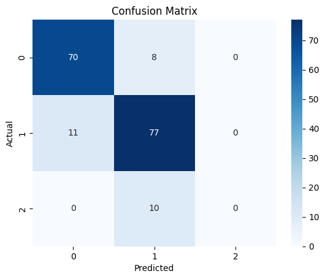

```python
# Menghitung akurasi
    accuracy = accuracy_score(y_test, y_pred)
    print(f"Akurasi: {accuracy:.2f}")

    # Menampilkan laporan klasifikasi
    print("\nClassification Report:")
    print(classification_report(y_test, y_pred))

    # Menampilkan Confusion Matrix
    conf_matrix = confusion_matrix(y_test, y_pred)
    sns.heatmap(conf_matrix, annot=True, fmt='d', cmap='Blues')
    plt.title('Confusion Matrix')
    plt.xlabel('Predicted')
    plt.ylabel('Actual')
    plt.show()
```

### Visualisasi Model

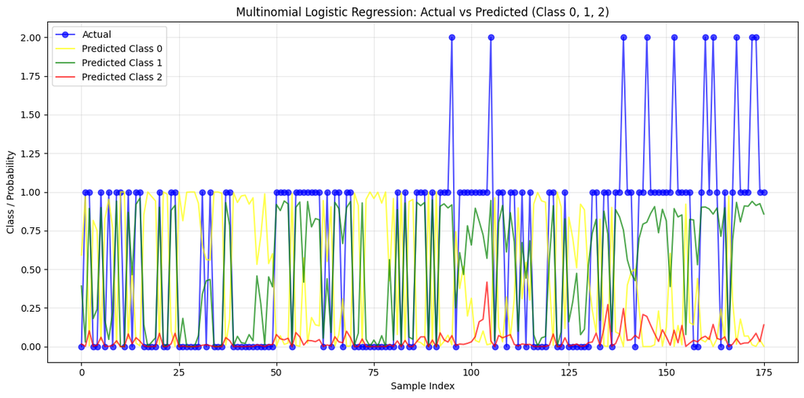

```python
import matplotlib.pyplot as plt
    import numpy as np

    # Membuat prediksi probabilitas untuk 3 kelas
    y_prob = model.predict_proba(X_test_scaled)  # Probabilitas untuk kelas 0, 1, 2

    # Mengurutkan data berdasarkan indeks asli
    sorted_indices = np.argsort(y_test.index)  # Mengurutkan indeks asli
    y_test_sorted = y_test.iloc[sorted_indices]
    y_prob_sorted = y_prob[sorted_indices]

    # Membuat plot
    plt.figure(figsize=(12, 6))

    # Plot nilai aktual (kelas 0, 1, 2)
    plt.plot(y_test_sorted.values, label='Actual', color='blue', marker='o', linestyle='-', alpha=0.7)

    # Plot probabilitas prediksi untuk setiap kelas
    plt.plot(y_prob_sorted[:, 0], label='Predicted Class 0', color='yellow', linestyle='-', alpha=0.7)
    plt.plot(y_prob_sorted[:, 1], label='Predicted Class 1', color='green', linestyle='-', alpha=0.7)
    plt.plot(y_prob_sorted[:, 2], label='Predicted Class 2', color='red', linestyle='-', alpha=0.7)

    # Menambahkan label, judul, dan legenda
    plt.title('Multinomial Logistic Regression: Actual vs Predicted (Class 0, 1, 2)')
    plt.xlabel('Sample Index')
    plt.ylabel('Class / Probability')
    plt.legend()
    plt.grid(alpha=0.3)
    plt.tight_layout()
    plt.show()
```

```python
# Menampilkan koefisien fitur
    coef_df = pd.DataFrame({'Feature': X.columns, 'Coefficient': model.coef_[0]})
    coef_df = coef_df.sort_values(by='Coefficient', ascending=False)
    print(coef_df)
```

```
   Feature  Coefficient
    8       Fe     0.188394
    9       Cu     0.173493
    4       EC     0.163111
    6        S     0.071570
    2        K     0.051651
    7       Zn    -0.005510
    10      Mn    -0.118052
    5       OC    -0.183648
    3       pH    -0.185680
    11       B    -0.537899
    1        P    -0.960460
    0        N    -3.135990
```